# What is a trace and why is it useful?

Duane Rich

February 11, 2018

Before we answer the question, we need to set some variables

```r
library(ggplot2)
remove_back <- function(g){
  g + theme_bw() + theme(panel.border = element_blank(), panel.grid.major = element_blank(),
panel.grid.minor = element_blank(), axis.line = element_line(colour = "black"))
}

n <- 100
x <- seq(1,n)/100
slope <- 3 #Slope of average line
freq <- 2
y_true <- x*slope + sin(x*2*pi*freq)
noise_std <- 1
y <- y_true + rnorm(n,0,noise_std)
df1 <- 5
df2 <- 15

smooth.matrix <-  function(x, df){
  n = length(x);
  A = matrix(0, n, n);
  for(i in 1:n){
    y = rep(0, n); y[i]=1;
    yi = smooth.spline(x, y, df=df)$y;
    A[,i]= yi;
    }
  (A+t(A))/2;
}
```

Set up both splines

```r
spline1 = smooth.spline(x,y,df=df1)
s_mat1 <- smooth.matrix(x,df1)
spline2 = smooth.spline(x,y,df=df2)
s_mat2 <- smooth.matrix(x,df2)

dat1 <- data.frame(x=x,y=y,yhat=spline1$y)
dat2 <- data.frame(x=x,y=y,yhat=spline2$y)
```

Structure:

Which one is better?

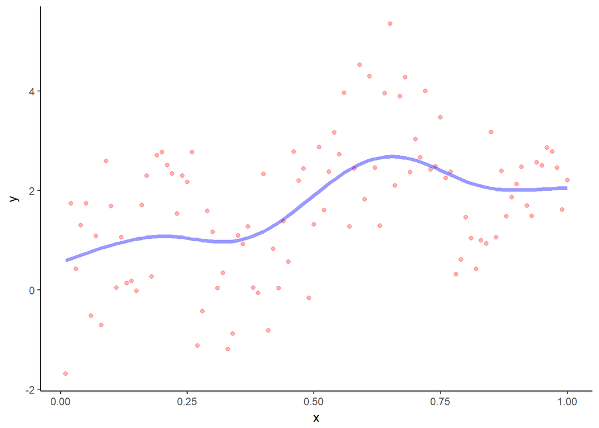

```r
make_spl_graph <- function(dat){
  g <- ggplot(dat,aes(x=x,y=y)) + geom_point(color='red',alpha=.3,size=1.5)
  g <- g + geom_line(aes(x, dat$yhat),color='blue',size=1.5,alpha=.4)
  g <- remove_back(g)
  g
}

make_spl_graph(dat1)
```

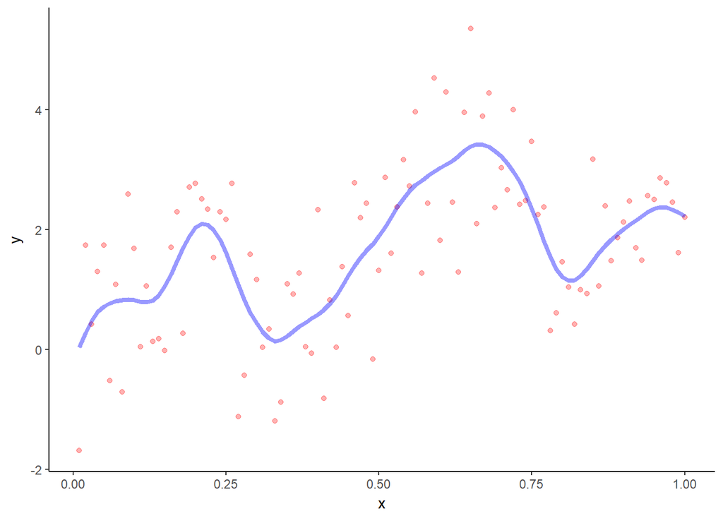

```r
make_spl_graph(dat2)
```

Seriously. There’s a correct answer here. Can you eye-ball and tell me which is best?

Maybe not, but a trace of a matrix could help us. Let me explain.

To answer the question of which is *best*, we need to define two things: the squiggle and what it means to be ‘best’.

The squiggle:

The most general way we could represent a squiggle is as a function $f(\cdot)$. You give it any $x$ between 0 and 1 and it’ll give you a $y$. Easy enough.

‘Best’:

Typically when faced with a problem like this, we assume the data is generated from some *true* function (call it $g(\cdot)$) plus some noise. That is:

$$y_i = g(x_i) + \epsilon_i$$
where $\{x_i\}$ and $\{y_i\}$ make up our observations and $\{\epsilon_i\}$. Let’s say a good $f(\cdot)$ is one that would approximate $g(\cdot)$ well.

So what?

OK, how would we ever figure that out? We can’t see $g(\cdot)$ - only those junky, noised-up $\{y_i\}$!. Unfortunately, in general, there isn’t a single solution to this problem, but we can do pretty well.

Let’s ask a slightly different question. What makes for a good squiggle? In other words, if I handed you two of them, how would decide which is best?

First, you definitely want it to fit the data. So let’s represent that fit with the typical sum of squares:

$$\sum_i (f(x_i) - y_i)^2$$
Larger numbers are bad. So, is that all? What if I gave you two functions that yield the same number for this? Then what? Well you might say pick the ‘smoother’ one. It’s akin to Occam’s Razor - pick the simpler function that does the same job. So if you remember calc, we can measure average (squared) smoothness of this function as

$$\int_0^1 f''(t)^2 dt$$

Ok, but how do weigh these two? Well I don’t know, so let’s leave that as a free parameter (call it $\lambda$) and add them together. So our criteria for a good function is one that yields a lower number of:

$$\textrm{loss}(f(\cdot),\lambda) = \sum_i (f(x_i) - y_i)^2 + \lambda \int_0^1 f''(t)^2 dt$$
That is, if I have a set preference for the fitness-smoothness tradeoff, then if you give me any two squiggles, I can tell you which is best!

Great, now check every possible squiggle and pick your favorite!

Fortunately for us, mathematicians have provided some mindblowing answers that avoid that cumbersome approach. The crazy thing is.. it’s identical to having taken that approach.

Those handy mathematicians discovered there is a unique, global optimum. It’s called a natural cubic spline, but let’s call it $s_\lambda(\cdot)$. That is

$$s_\lambda(\cdot) = \textrm{argmin}_{f(\cdot)} \textrm{loss}(f(\cdot),\lambda)$$
Now, here’s the absolutely mind-blowing part. There exists a matrix $\mathbf{S}_\lambda$ that only depends on our $x_i$’s and our $\lambda$ such that:

$$s_\lambda(\mathbf{x}) = \mathbf{S}_\lambda\mathbf{y}$$

where $\mathbf{x}$ is just a vector of our $x_i$’s (similarily for $\mathbf{y}$).

Think about why that’s crazy. If know just the inputs ($x_i$’s) and I have my fitness-smoothness tradeoff set, then the moment you hand me $y_i$’s, I’m one matrix multiplication away from knowing the global optimizer of $\textrm{loss}(f(\cdot),\lambda)$.